# R Notebook

## 16.4 Bayesian Statistics

What does it mean when an election forecaster tells us that a given candidate has 90% chance of winning?: probability p>0.5 is 90%. However, in the urn model p is a fixed parameter so it doesn’t make sense to talk about probability. Bayesian statistics; we model p as random variable.

Forecasters also use models to describe variability at different levels. One of the most successful approaches used for this are hierarchical models, which can be explained in the context of Bayesian statistics.

### 16.4.1 Bayes Theorem

Hypothetical cystic fibrosis test; accuracy of 99%.

$\mbox{Prob}(+ \mid D=1)=0.99, \mbox{Prob}(- \mid D=0)=0.99$

- : positive test, D : if you actually have the disease (1) or not (0).

suppose we select a random person and they test positive ; what is the probability that they have the disease?

$\mbox{Pr}(D=1 \mid +) = \frac{ P(+ \mid D=1) \cdot P(D=1)} {\mbox{Pr}(+)}$ = $\frac{\mbox{Pr}(+ \mid D=1)\cdot P(D=1)} {\mbox{Pr}(+ \mid D=1) \cdot P(D=1) + \mbox{Pr}(+ \mid D=0) \mbox{Pr}( D=0)}$

Despite the test having 0.99 accuracy, the probability of having the disease given a positive test is only 0.02. The reason this is the case is because we have to factor in the very rare probability that a person, chosen at random, has the disease.

## 16.5 Bayes theorem simulation

We start by randomly selecting 100,000 people from a population in which the disease in question has a 1 in 4,000 prevalence.

```r
prev <- 0.00025
N <- 100000
outcome <- sample(c("Disease","Healthy"), N, replace = TRUE,
                  prob = c(prev, 1 - prev))
```

```r
N_D <- sum(outcome == "Disease")
N_D
```

```
[1] 33
```

```r
N_H <- sum(outcome == "Healthy")
N_H
```

```
[1] 99967
```

There are very few people with the disease, and many without disease >> we’ll see some false positives given that the test is not perfect.

```r
accuracy <- 0.99
test <- vector("character", N)
test[outcome == "Disease"]  <- sample(c("+", "-"), N_D, replace = TRUE,
                                    prob = c(accuracy, 1 - accuracy))
test[outcome == "Healthy"]  <- sample(c("-", "+"), N_H, replace = TRUE,
                                    prob = c(accuracy, 1 - accuracy))
```

Because there are so many more controls than cases, even with a low false positive rate we get more controls than cases in the group that tested positive:

```r
table(outcome, test)
```

```
         test
outcome       -     +
  Disease     0    33
  Healthy 98965  1002
```

### 16.5.1 Bayes in practice

The batting average (AVG) statistic gives us success rate when batting. An AVG of .450 means José has been successful 45% of the times he has batted (At Bats)

To illustrate the way hierarchical models are powerful, we will try to predict José’s batting average at the end of the season. Note that in a typical season, players have about 500 at bats.

The best we can do is provide a confidence interval. We can think of outcomes from hitting as a binomial with a success rate of p.

So if the success rate is indeed .450, the standard error of just 20 at bats is:

$\sqrt{\frac{.450 (1-.450)}{20}}=.111$

our confidence interval is .450-.220 to .450+.222

Two problems: 1. Large 2. Centered at .450 >> this new player will break Ted Williams’ record

The distribution of batting averages for all players with more than 500 at bats during the previous three seasons >> The average player had an AVG of .275 and the standard deviation of the population of players was 0.027. So we can see already that .450 would be quite an anomaly.

## 16.6 Hierarchical models

The hierarchical model provides a mathematical description of how we came to see the observation of .450. First, we pick a player at random with an intrinsic ability summarized by p. Then we see 20 random outcomes with success probability p.

If we add up these successes and failures, then the CLT tells us that the observed average, call it Y, has a normal distribution with expected value p and standard error $\sqrt{p(1-p)/N}$ with N the number of at bats.

p∼N(μ,τ2) Y∣p∼N(p,σ2)

~ symbol: tells us the random variable on the left of the symbol follows the distribution on the right, and N(a, b^2) represents the normal distribution with mean a, standard deviation b. | : conditioned on. we are treating the random variable on the right of the symbol as known.

We refer to the model as hierarchical because we need to know p in order to model Y. In our example the first level p describes randomness in assigning talent to a player and the second Y describes randomness in this particular player’s performance once we have fixed the talent parameter.

In a Bayesian framework, the first level is called a prior distribution and the second the sampling distribution.

$p \sim N(.275, .027^2)$ $Y \mid p \sim N(p, .111^2)$

The continuous version of Bayes’ rule can be used here to derive the posterior probability function, which is the distribution of p, assuming we observe Y=y.

When we fix Y=y, p follows a normal distribution with expected value:

$E(p \mid Y=y) = B \mu + (1-B) y$ $= \mu + (1-B)(y-\mu)$ $\mbox{with } B = \frac{\sigma^2}{\sigma^2+\tau^2}$

This is a weighted average of the population average μ and the observed data y. The weight depends on the SD of the population τ and the SD of our observed data  
σ. This weighted average is sometimes referred to as shrinking because it shrinks estimates towards a prior mean.

$\mbox{E}(p \mid Y=.450) = B \times .275 + (1 - B) \times .450$ $= .275 + (1 - B)(.450 - .275)$ $B =\frac{.111^2}{.111^2 + .027^2} = 0.944$ $\mbox{E}(p \mid Y=450) \approx .285$

standard error: $\mbox{SE}(p\mid y)^2 = \frac{1}{1/\sigma^2+1/\tau^2}= \frac{1}{1/.111^2 + 1/.027^2} = 0.00069$

standard deviation: and the standard deviation is therefore 0.026.

So we started with a frequentist 95% confidence interval that ignored data from other players and summarized just José’s data: .450 ± 0.220. Then we used a Bayesian approach that incorporated data from other players and other years to obtain a posterior probability. This is actually referred to as an empirical Bayes approach because we used data to construct the prior. From the posterior, we can report what is called a 95% credible interval by reporting a region, centered at the mean, with a 95% chance of occurring. In our case, this turns out to be: .285 ± 0.052.

The Bayesian credible interval suggests that if another team is impressed by the .450 observation, we should consider trading José as we are predicting he will be just slightly above average.

## 16.7 Exercises

1. In 1999, in England, Sally Clark58 was found guilty of the murder of two of her sons. Both infants were found dead in the morning, one in 1996 and another in 1998. In both cases, she claimed the cause of death was sudden infant death syndrome (SIDS). No evidence of physical harm was found on the two infants so the main piece of evidence against her was the testimony of Professor Sir Roy Meadow, who testified that the chances of two infants dying of SIDS was 1 in 73 million. He arrived at this figure by finding that the rate of SIDS was 1 in 8,500 and then calculating that the chance of two SIDS cases was 8,500×8,500≈73 million. Which of the following do you agree with?

2. Let’s assume that there is in fact a genetic component to SIDS and the probability of Pr(second case of SIDS∣first case of SIDS)=1/100, is much higher than 1 in 8,500. What is the probability of both of her sons dying of SIDS?

```r
Pr1 <- 1/8500
Pr2 <- 1/100
Pr1*Pr2
```

```
[1] 1.176471e-06
```

3. Many press reports stated that the expert claimed the probability of Sally Clark being innocent as 1 in 73 million. Perhaps the jury and judge also interpreted the testimony this way. This probability can be written as the probability of a mother is a son-murdering psychopath given that two of her children are found dead with no evidence of physical harm. According to Bayes’ rule, what is this?

```r
(1 / 8500) * (1 / 100)
```

4. Assume that the chance of a son-murdering psychopath finding a way to kill her children, without leaving evidence of physical harm, is:

Pr(A∣B)=0.50

with A = two of her children are found dead with no evidence of physical harm and B = a mother is a son-murdering psychopath = 0.50. Assume that the rate of son-murdering psychopaths mothers is 1 in 1,000,000. According to Bayes’ theorem, what is the probability of Pr(B∣A)?

```r
pr_ab <- 0.5
pr_b <- 1 / 1000000
pr_abc <- 0.5 / (1 / 1000000) * (1 - 1 / 1000000)
pr_bc <- 1 - 1 / 1000000
pr_ba <- pr_ab * pr_b / (pr_ab * pr_b + pr_abc * pr_bc)
pr_ba
```

```
[1] 1.000002e-12
```

5. After Sally Clark was found guilty, the Royal Statistical Society issued a statement saying that there was “no statistical basis” for the expert’s claim. They expressed concern at the “misuse of statistics in the courts”. Eventually, Sally Clark was acquitted in June 2003. What did the expert miss?

6. Florida is one of the most closely watched states in the U.S. election because it has many electoral votes, and the election is generally close, and Florida tends to be a swing state that can vote either way. Create the following table with the polls taken during the last two weeks:

```r
library(tidyverse)
library(dslabs)
data(polls_us_election_2016)
polls <- polls_us_election_2016 %>%
  filter(state == "Florida" & enddate >= "2016-11-04" ) %>%
  mutate(spread = rawpoll_clinton/100 - rawpoll_trump/100)
```

Take the average spread of these polls. The CLT tells us this average is approximately normal. Calculate an average and provide an estimate of the standard error. Save your results in an object called results.

```r
results <- polls %>% summarize(avg = mean(spread),  se = sd(spread)/sqrt(n()))
results
```

| avg | se |
| --- | --- |
| 0.004154545 | 0.007218692 |

7. Now assume a Bayesian model that sets the prior distribution for Florida’s election night spread d to be Normal with expected value μ and standard deviation τ. What are the interpretations of μ and τ?

A. μ and τ are arbitrary numbers that let us make probability statements about d. **B. μ and τ summarize what we would predict for Florida before seeing any polls. Based on past elections, we would set μ close to 0 because both Republicans and Democrats have won, and τ at about 0.02, because these elections tend to be close.** C. μ and τ summarize what we want to be true. We therefore set μ at 0.10 and τ at 0.01. D. The choice of prior has no effect on Bayesian analysis.

8. The CLT tells us that our estimate of the spread ^d has normal distribution with expected value d and standard deviation σ calculated in problem 6. Use the formulas we showed for the posterior distribution to calculate the expected value of the posterior distribution if we set μ=0 and τ=0.01.

```r
sigma <- results$se
Y <- results$avg
tau <- 0.01
miu <- 0
B <- sigma^2 / (sigma^2 + tau^2)
B
```

```
[1] 0.342579
```

```r
estimate <- miu + (1 - B) * (Y - miu)
estimate
```

```
[1] 0.002731286
```

9. Now compute the standard deviation of the posterior distribution.

```r
se <- sqrt(1/(1/sigma^2+1/tau^2))
se
```

```
[1] 0.005853024
```

10. Using the fact that the posterior distribution is normal, create an interval that has a 95% probability of occurring centered at the posterior expected value. Note that we call these credible intervals.

```r
ci <- c(estimate - qnorm(0.975) * se, estimate + qnorm(0.975) * se)
ci
```

```
[1] -0.008740432  0.014203003
```

11. According to this analysis, what was the probability that Trump wins Florida?

```r
pnorm(0, estimate, se)
```

```
[1] 0.3203769
```

12. Now use sapply function to change the prior variance from seq(0.005, 0.05, len = 100) and observe how the probability changes by making a plot.

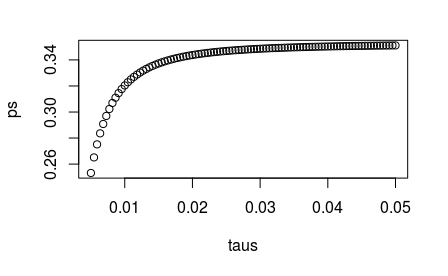

```r
taus <- seq(0.005, 0.05, len = 100)
p_calc <- function(tau) {
  B <- sigma^2 / (sigma^2 + tau^2)
  est <- miu + (1 - B) * (Y - miu)
  se <- sqrt(1/(1/sigma^2+1/tau^2))
  pnorm(0, estimate, se)
}
ps <- sapply(taus, p_calc)
plot(taus, ps)
```

## 16.8 Case study: election forecasting

In a previous section, we generated these data tables:

```r
library(tidyverse)
library(dslabs)
polls <- polls_us_election_2016 %>%
  filter(state == "U.S." & enddate >= "2016-10-31" &
           (grade %in% c("A+","A","A-","B+") | is.na(grade))) %>%
  mutate(spread = rawpoll_clinton/100 - rawpoll_trump/100)
one_poll_per_pollster <- polls %>% group_by(pollster) %>%
  filter(enddate == max(enddate)) %>%
  ungroup()
results <- one_poll_per_pollster %>%
  summarize(avg = mean(spread), se = sd(spread)/sqrt(length(spread))) %>%
  mutate(start = avg - 1.96*se, end = avg + 1.96*se)
```

Below, we will use these for our forecasting.

### 16.8.1 Bayesian approach

Pollsters tend to make probabilistic statements about the results of the election. For example, “The chance that Obama wins the electoral college is 91%” is a probabilistic statement about a parameter which in previous sections we have denoted with d. We showed that for the 2016 election, FiveThirtyEight gave Clinton an 81.4% chance of winning the popular vote. To do this, they used the Bayesian approach we described.

We assume a hierarchical model similar to what we did to predict the performance of a baseball player. Statistical textbooks will write the model like this:

$$\begin{aligned}d&∼N(μ,τ^2)describes\ our\ best\ guess\ had\ we\ not\ seen\ any\ polling\ data\\\bar{X}∣d&∼N
(d,σ^2)describes\ randomness\ due\ to\ sampling\ and\ the\ pollster\ effect\end{aligned}$$

For our best guess, we note that before any poll data is available, we can use data sources other than polling data. A popular approach is to use what pollsters call fundamentals, which are based on properties about the current economy that historically appear to have an effect in favor or against the incumbent party. We won’t use these here. Instead, we will use μ=0, which is interpreted as a model that simply does not provide any information on who will win. For the standard deviation, we will use recent historical data that shows the winner of the popular vote has an average spread of about 3.5%. Therefore, we set τ=0.035.

Now we can use the formulas for the posterior distribution for the parameter d: the probability of d>0 given the observed poll data:

```r
mu <- 0
tau <- 0.035
sigma <- results$se
Y <- results$avg
B <- sigma^2 / (sigma^2 + tau^2)
posterior_mean <- B*mu + (1-B)*Y
posterior_se <- sqrt( 1/ (1/sigma^2 + 1/tau^2))
posterior_mean
```

```
[1] 0.02808534
```

```r
posterior_se
```

```
[1] 0.006149604
```

To make a probability statement, we use the fact that the posterior distribution is also normal. And we have a credible interval of:

```r
posterior_mean + c(-1.96, 1.96)*posterior_se
```

```
[1] 0.01603212 0.04013857
```

The posterior probability $Pr(d>0∣\bar{X})$ can be computed like this:

```r
1 - pnorm(0, posterior_mean, posterior_se)
```

```
[1] 0.9999975
```

This says we are 100% sure Clinton will win the popular vote, which seems too overconfident. Also, it is not in agreement with FiveThirtyEight’s 81.4%. What explains this difference?

### 16.8.2 The general bias

After elections are over, one can look at the difference between pollster predictions and actual result. An important observation that our model does not take into account is that it is common to see a general bias that affects many pollsters in the same way making the observed data correlated. There is no good explanation for this, but we do observe it in historical data: in one election, the average of polls favors Democrats by 2%, then in the following election they favor Republicans by 1%, then in the next election there is no bias, then in the following one Republicans are favored by 3%, and so on. In 2016, the polls were biased in favor of the Democrats by 1-2%.

Although we know this bias term affects our polls, we have no way of knowing what this bias is until election night. So we can’t correct our polls accordingly. What we can do is include a term in our model that accounts for this variability.

### 16.8.3 Mathematical representations of models

Suppose we are collecting data from one pollster and we assume there is no general bias. The pollster collects several polls with a sample size of N, so we observe several measurements of the spread $X_1,…,X_J$. The theory tells us that these random variables have expected value $d$ and standard error $2\sqrt{p(1−p)/N}$. Let’s start by using the following model to describe the observed variability:
$$X_j=d+ε_j$$

We use the index j to represent the different polls and we define $ε_j$ to be a random variable that explains the poll-to-poll variability introduced by sampling error. To do this, we assume its average is 0 and standard error is $2\sqrt{p(1−p)/N$. If d is 0.021 and the sample size for these polls is 2,000, we can simulate J=6 data points from this model like this:

```r
set.seed(3)
J <- 6
N <- 2000
d <- .021
p <- (d + 1)/2
X <- d + rnorm(J, 0, 2 * sqrt(p * (1 - p) / N))
```

Now suppose we have J=6 data points from I=5 different pollsters. To represent this we now need two indexes, one for pollster and one for the polls each pollster takes. We use $X_{ij}$ with i representing the pollster and j representing the j-th poll from that pollster. If we apply the same model, we write:
$$X_{i,j}=d+ε{i,j}$$
To simulate data, we now have to loop through the pollsters:

```r
I <- 5
J <- 6
N <- 2000
X <- sapply(1:I, function(i){
  d + rnorm(J, 0, 2 * sqrt(p * (1 - p) / N))
})
```

The model above does not account for pollster-to-pollster variability. To fix this, we add a new term for the pollster effect. We will use $h_i$ to represent the house effect of the $i$-th pollster. The model is now augmented to:
$$X_{i,j}=d+h_i+ε_{i,j}$$

To simulate data from a specific pollster, we now need to draw an $h_i$ and then add the $ε$s. Here is how we would do it for one specific pollster. We assume $σ_h$ is 0.025:

```r
I <- 5
J <- 6
N <- 2000
d <- .021
p <- (d + 1) / 2
h <- rnorm(I, 0, 0.025)
X <- sapply(1:I, function(i){
  d + h[i] + rnorm(J, 0, 2 * sqrt(p * (1 - p) / N))
})
```

Now, in the model above, we assume the average house effect is 0. We think that for every pollster biased in favor of our party, there is another one in favor of the other and assume the standard deviation is $σ_h$. But historically we see that every election has a general bias affecting all polls.

We can observe this with the 2016 data, but if we collect historical data, we see that the average of polls misses by more than models like the one above predict. To see this, we would take the average of polls for each election year and compare it to the actual value. If we did this, we would see a difference with a standard deviation of between 2-3%. To incorporate this into the model, we can add another term to account for this variability:
$$X_{i,j}=d+b+h_i+ε_{i,j}$$
.

Here $b$ is a random variable that accounts for the election-to-election variability. This random variable changes from election to election, but for any given election, it is the same for all pollsters and polls within on election. This is why it does not have indexes. This implies that all the random variables $X_{i,j$ for an election year are correlated since they all have $b$ in common.

One way to interpret $b$ is as the difference between the average of all polls from all pollsters and the actual result of the election. Because we don’t know the actual result until after the election, we can’t estimate $b$ until after the election. However, we can estimate $b$ from previous elections and study the distribution of these values. Based on this approach we assume that, across election years, $b$ has expected value 0 and the standard error is about $σ_b=0.025$.

An implication of adding this term to the model is that the standard deviation for $X_{i,j}$ is actually higher than what we earlier called $σ$, which combines the pollster variability and the sample in variability, and was estimated with:

```r
sd(one_poll_per_pollster$spread)
```

This estimate does not include the variability introduced by $b$.

Note that because

$$\bar{X}=d+b+\frac{1}{N}\sum^N_{i=1}X_i,$$
the standard deviation of $\bar{X}$ is:
$$\sqrt{σ^2/N+σ^2_b.$$
Since the same $b$ is in every measurement, the average does not reduce the variability introduced by the $b$ term. This is an important point: it does not matter how many polls you take, this bias does not get reduced.

```r
mu <- 0
tau <- 0.035
sigma <- sqrt(results$se^2 + .025^2)
Y <- results$avg
B <- sigma^2 / (sigma^2 + tau^2)
posterior_mean <- B*mu + (1-B)*Y
posterior_se <- sqrt( 1/ (1/sigma^2 + 1/tau^2))
1 - pnorm(0, posterior_mean, posterior_se)
```

### 16.8.4 Predicting the electoral college

```r
results_us_election_2016 %>% top_n(5, electoral_votes)
```

With some minor exceptions we don’t discuss, the electoral votes are won all or nothing. For example, if you win California by just 1 vote, you still get all 55 of its electoral votes. This means that by winning a few big states by a large margin, but losing many small states by small margins, you can win the popular vote and yet lose the electoral college. This happened in 1876, 1888, 2000, and 2016. The idea behind this is to avoid a few large states having the power to dominate the presidential election. Nonetheless, many people in the US consider the electoral college unfair and would like to see it abolished.

We are now ready to predict the electoral college result for 2016. We start by aggregating results from a poll taken during the last week before the election. We use the `str_detect`, to remove polls that are not for entire states.

```r
results <- polls_us_election_2016 %>%
  filter(state!="U.S." &
           !str_detect(state, "CD") &
           enddate >="2016-10-31" &
           (grade %in% c("A+","A","A-","B+") | is.na(grade))) %>%
  mutate(spread = rawpoll_clinton/100 - rawpoll_trump/100) %>%
  group_by(state) %>%
  summarize(avg = mean(spread), sd = sd(spread), n = n()) %>%
  mutate(state = as.character(state))
```

```r
results %>% arrange(abs(avg))
```

We now introduce the command `left_join` that will let us easily add the number of electoral votes for each state from the dataset `us_electoral_votes_2016`. We will describe this function in detail in the Wrangling chapter. Here, we simply say that the function combines the two datasets so that the information from the second argument is added to the information in the first:

```r
results <- left_join(results, results_us_election_2016, by = "state")
```

Notice that some states have no polls because the winner is pretty much known:

```r
results_us_election_2016 %>% filter(!state %in% results$state) %>%
  pull(state)
```

Because we can’t estimate the standard deviation for states with just one poll, we will estimate it as the median of the standard deviations estimated for states with more than one poll:

```r
results <- results %>%
  mutate(sd = ifelse(is.na(sd), median(results$sd, na.rm = TRUE), sd))
```

To make probabilistic arguments, we will use a Monte Carlo simulation. For each state, we apply the Bayesian approach to generate an election day $d$. We could construct the priors for each state based on recent history. However, to keep it simple, we assign a prior to each state that assumes we know nothing about what will happen. Since from election year to election year the results from a specific state don’t change that much, we will assign a standard deviation of 2% or $τ=0.02$. For now, we will assume, incorrectly, that the poll results from each state are independent.

```r
B <- 10000
mu <- 0
tau <- 0.02
clinton_EV <- replicate(B, {
  results %>% mutate(sigma = sd/sqrt(n),
                   B = sigma^2 / (sigma^2 + tau^2),
                   posterior_mean = B * mu + (1 - B) * avg,
                   posterior_se = sqrt(1 / (1/sigma^2 + 1/tau^2)),
                   result = rnorm(length(posterior_mean),
                                  posterior_mean, posterior_se),
                   clinton = ifelse(result > 0, electoral_votes, 0)) %>%
    summarize(clinton = sum(clinton)) %>%
    pull(clinton) + 7
})
mean(clinton_EV > 269)
```

[output not shown]

The model above ignores the general bias and assumes the results from different states are independent. After the election, we realized that the general bias in 2016 was not that big: it was between 1 and 2%. But because the election was close in several big states and these states had a large number of polls, pollsters that ignored the general bias greatly underestimated the standard error. Using the notation we introduce, they assumed the standard error was $\sqrt{σ^2/N}$ which with large N is quite smaller than the more accurate estimate $\sqrt{σ^2/N+σ^2_b}$. FiveThirtyEight, which models the general bias in a rather sophisticated way, reported a closer result. We can simulate the results now with a bias term. For the state level, the general bias can be larger so we set it at $σ_b=0.03$:

```r
tau <- 0.02
bias_sd <- 0.03
clinton_EV_2 <- replicate(1000, {
  results %>% mutate(sigma = sqrt(sd^2/n  + bias_sd^2),
                   B = sigma^2 / (sigma^2 + tau^2),
                   posterior_mean = B*mu + (1-B)*avg,
                   posterior_se = sqrt( 1/ (1/sigma^2 + 1/tau^2)),
                   result = rnorm(length(posterior_mean),
                                  posterior_mean, posterior_se),
                   clinton = ifelse(result>0, electoral_votes, 0)) %>%
    summarize(clinton = sum(clinton) + 7) %>%
    pull(clinton)
})
mean(clinton_EV_2 > 269)
```

FiveThirtyEight includes many other features we do not include here. One is that they model variability with distributions that have high probabilities for extreme events compared to the normal. One way we could do this is by changing the distribution used in the simulation from a normal distribution to a t-distribution. FiveThirtyEight predicted a probability of 71%.

### 16.8.5 Forecasting

Forecasters like to make predictions well before the election. The predictions are adapted as new polls come out. However, an important question forecasters must ask is: how informative are polls taken several weeks before the election about the actual election? Here we study the variability of poll results across time. To make sure the variability we observe is not due to pollster effects, let’s study data from one pollster:

```r
one_pollster <- polls_us_election_2016 %>%
  filter(pollster == "Ipsos" & state == "U.S.") %>%
  mutate(spread = rawpoll_clinton/100 - rawpoll_trump/100)
```

Since there is no pollster effect, then perhaps the theoretical standard error matches the data-derived standard deviation. We compute both here:

```r
se <- one_pollster %>%
  summarize(empirical = sd(spread),
            theoretical = 2 * sqrt(mean(spread) * (1 - mean(spread)) /
                                     min(samplesize)))
se
```

[output not shown]

This implies that, if we are going to forecast, our model must include a term to accounts for the time effect. We need to write a model including a bias term for

time:
$$Y_{i,j,t}=d+b+h_j+b_t+ε_{i,j,t}$$

The standard deviation of $b_t$ would depend on $t$ since the closer we get to election day, the closer to 0 this bias term should be.

$$Y_{i,j,t}=d+b+h_j+b_t+f(t)+ε_{i,j,t}$$
We usually see the estimated $f(t)$ not for the difference.

Once a model like the one above is selected, we can use historical and present data to estimate all the necessary parameters to make predictions. There is a variety of methods for estimating trends $f(t)$ which we discuss in the Machine Learning part.

## 16.9 Exercises

1. Create this table:

```r
library(tidyverse)
library(dslabs)
data("polls_us_election_2016")
polls <- polls_us_election_2016 %>%
  filter(state != "U.S." & enddate >= "2016-10-31") %>%
  mutate(spread = rawpoll_clinton/100 - rawpoll_trump/100)
```

Now for each poll use the CLT to create a 95% confidence interval for the spread reported by each poll. Call the resulting object cis with columns lower and upper for the limits of the confidence intervals. Use the `select` function to keep the columns `state, startdate, end date, pollster, grade, spread, lower, upper`.

```r
cis <- polls %>% mutate(x_hat = (spread + 1) / 2, se_hat = 2*sqrt((x_hat * (1 - x_hat)) / samplesize), lower = x_hat - qnorm(0.975) * se_hat, upper = x_hat + qnorm(0.975) * se_hat) %>% select(state, startdate, enddate, pollster, grade, spread, lower, upper)
```

2. You can add the final result to the `cis` table you just created using the `right_join` function like this:

```r
add <- results_us_election_2016 %>%
  mutate(actual_spread = clinton/100 - trump/100) %>%
  select(state, actual_spread)
cis <- cis %>%
  mutate(state = as.character(state)) %>%
  left_join(add, by = "state")
```

Now determine how often the 95% confidence interval includes the actual result.

```r
cis %>% mutate(include = actual_spread >= lower & actual_spread <= upper) %>% summarise(mean(include == TRUE))
```

3. Repeat this, but show the proportion of hits for each pollster. Show only pollsters with more than 5 polls and order them from best to worst. Show the number of polls conducted by each pollster and the FiveThirtyEight grade of each pollster. Hint: use `n=n(), grade = grade[1]` in the call to summarize.

```r
hit <- cis %>% mutate(include = actual_spread >= lower & actual_spread <= upper) %>%
  group_by(pollster) %>%
  filter(n() > 5) %>%
  summarize(proportion_hit = mean(include), n = n(), grade = grade[1])
hit
```

4. Repeat exercise 3, but instead of pollster, stratify by state. Note that here we can’t show grades.

```r
hit <- cis %>% mutate(include = actual_spread >= lower & actual_spread <= upper) %>%
  group_by(state) %>%
  filter(n() > 5) %>%
  summarize(proportion_hit = mean(include), n = n())
hit
```

5. Make a barplot based on the result of exercise 4. Use `coord_flip`.

```r
hit %>% mutate(state = reorder(state, proportion_hit)) %>%
  ggplot(aes(state, proportion_hit)) + geom_bar(stat = "identity") + coord_flip()
```

6. Add two columns to the `cis` table by computing, for each poll, the difference between the predicted spread and the actual spread, and define a column `hit` that is true if the signs are the same. Hint: use the function `sign`. Call the object `resids`.

```r
resids <- cis %>% mutate(error = spread - actual_spread, hit = sign(spread)==sign(actual_spread))
```

7. Create a plot like in exercise 5, but for the proportion of times the sign of the spread agreed.

```r
hit <- resids %>% group_by(state) %>%
  filter(n()>5) %>%
  summarize(proportion_hit = mean(hit), n = n())
hit %>% mutate(state = reorder(state, proportion_hit)) %>%
  ggplot(aes(state, proportion_hit)) +
  geom_bar(stat = "identity") +
  coord_flip()
```

```r
hist(resids$error)
median(resids$error)
```

```r
resids %>% filter(grade %in% c("A+","A","A-","B+") | is.na(grade)) %>%
  mutate(state = reorder(state, error)) %>%
  ggplot(aes(state, error)) +
  theme(axis.text.x = element_text(angle = 45, hjust = 1)) +
  geom_boxplot() +
  geom_point()
```

10. Some of these states only have a few polls. Repeat exercise 9, but only include states with 5 good polls or more. Hint: use `group_by`, `filter` then `ungroup`. You will see that the West (Washington, New Mexico, California) underestimated Hillary’s performance, while the Midwest (Michigan, Pennsylvania, Wisconsin, Ohio, Missouri) overestimated it. In our simulation, we did not model this behavior since we added general bias, rather than a regional bias. Note that some pollsters may now be modeling correlation between similar states and estimating this correlation from historical data. To learn more about this, you can learn about random effects and mixed models.

```r
resids %>% filter(grade %in% c("A+","A","A-","B+") | is.na(grade)) %>%
  mutate(state = reorder(state, error)) %>%
  group_by(state) %>%
  filter(n()>5) %>%
  ungroup() %>%
  ggplot(aes(state, error)) +
  theme(axis.text.x = element_text(angle = 45, hjust = 1)) +
  geom_boxplot() +
  geom_point()
```

## 16.10 The t-distribution

Above we made use of the CLT with a sample size of 15. Because we are estimating a second parameters $σ$, further variability is introduced into our confidence interval which results in intervals that are too small. For very large sample sizes this extra variability is negligible, but, in general, for values smaller than 30 we need to be cautious about using the CLT.

However, if the data in the urn is known to follow a normal distribution, then we actually have mathematical theory that tells us how much bigger we need to make the intervals to account for the estimation of $σ$. Using this theory, we can construct confidence intervals for any $N$. But again, this works only if the data in the urn is known to follow a normal distribution.

So for the 0, 1 data of our previous urn model, this theory definitely does not apply. The statistic on which confidence intervals for $d$ are based is
$$Z=\frac{\bar{X}−d}{σ/\sqrt{N}}$$
CLT tells us that Z is approximately normally distributed with expected value 0 and standard error 1. But in practice we don’t know $σ$ so we use:

$$Z=\frac{\bar{X}−d}{s/\sqrt{N}}$$
By substituting $σ$ with $s$ we introduce some variability. The theory tells us that $Z$ follows a t-distribution with $N−1$ degrees of freedom. The degrees of freedom is a parameter that controls the variability via fatter tails.

If we are willing to assume the pollster effect data is normally distributed, based on the sample data $X_1,…,X_N$,

```r
one_poll_per_pollster %>%
  ggplot(aes(sample=spread)) + stat_qq()
```

then $Z$ follows a t-distribution with $N−1$ degrees of freedom. So perhaps a better confidence interval for $d$ is:

```r
z <- qt(0.975,  nrow(one_poll_per_pollster)-1)
one_poll_per_pollster %>%
  summarize(avg = mean(spread), moe = z*sd(spread)/sqrt(length(spread))) %>%
  mutate(start = avg - moe, end = avg + moe)
```

```r
qt(0.975, 14)
```

is bigger than

```r
qnorm(0.975)
```

The t-distribution can also be used to model errors in bigger deviations that are more likely than with the normal distribution, as seen in the densities we previously saw. Fivethirtyeight uses the t-distribution to generate errors that better model the deviations we see in election data. For example, in Wisconsin the average of six polls was 7% in favor of Clinton with a standard deviation of 1%, but Trump won by 0.7%. Even after taking into account the overall bias, this 7.7% residual is more in line with t-distributed data than the normal distribution.

```r
data("polls_us_election_2016")
polls_us_election_2016 %>%
  filter(state =="Wisconsin" &
           enddate >="2016-10-31" &
           (grade %in% c("A+","A","A-","B+") | is.na(grade))) %>%
  mutate(spread = rawpoll_clinton/100 - rawpoll_trump/100) %>%
  mutate(state = as.character(state)) %>%
  left_join(results_us_election_2016, by = "state") %>%
  mutate(actual = clinton/100 - trump/100) %>%
  summarize(actual = first(actual), avg = mean(spread),
            sd = sd(spread), n = n()) %>%
  select(actual, avg, sd, n)
```